# Regresja Logistyczna

Jakub Myśliwiec, Filip Twardy

## Zbiór danych

Pracujemy na zbiorze danych Breast Cancer Wisconsin (Diagnostic) Data Set. Zawiera on: * 33 kolumny * 569 wierszy Cechy opisuję właściwości jąder komórkowych widocznych na obrazie FNA piersi. Zbiór zawiera jedną cechę kategoryczną *diagnosis*, która określa czy nowotwór jest * złośliwy (M = malignant) * łagodny (B = benign)

```r
names(ds)
```

```
##  [1] "id"                      "diagnosis"
##  [3] "radius_mean"             "texture_mean"
##  [5] "perimeter_mean"          "area_mean"
##  [7] "smoothness_mean"         "compactness_mean"
##  [9] "concavity_mean"          "concave.points_mean"
## [11] "symmetry_mean"           "fractal_dimension_mean"
## [13] "radius_se"               "texture_se"
## [15] "perimeter_se"            "area_se"
## [17] "smoothness_se"           "compactness_se"
## [19] "concavity_se"            "concave.points_se"
## [21] "symmetry_se"             "fractal_dimension_se"
## [23] "radius_worst"            "texture_worst"
## [25] "perimeter_worst"         "area_worst"
## [27] "smoothness_worst"        "compactness_worst"
## [29] "concavity_worst"         "concave.points_worst"
## [31] "symmetry_worst"          "fractal_dimension_worst"
## [33] "X"
```

```r
dim(ds)
```

```
## [1] 569  33
```

```r
# removing last columns as it's full of NA values
ds = ds[-33]
dim(ds)
```

```
## [1] 569  32
```

## Regresja logistyczna

Postanowiliśmy przewidywać wartość diagnozy na podstawie wszystkich pozostałych parametrów, z wyjątkiem *id*. Zaczęliśmy od zakodowania wartości *“M”* jako 1 i *“B”* jako 0.

```r
ds$outcome[ds$diagnosis=="M"] = 1
ds$outcome[ds$diagnosis=="B"] = 0
ds$outcome = as.integer(ds$outcome)
head(ds)
```

```
##         id diagnosis radius_mean texture_mean perimeter_mean area_mean
## 1   842302         M       17.99        10.38         122.80    1001.0
## 2   842517         M       20.57        17.77         132.90    1326.0
## 3 84300903         M       19.69        21.25         130.00    1203.0
## 4 84348301         M       11.42        20.38          77.58     386.1
## 5 84358402         M       20.29        14.34         135.10    1297.0
## 6   843786         M       12.45        15.70          82.57     477.1
##   smoothness_mean compactness_mean concavity_mean concave.points_mean
## 1         0.11840          0.27760         0.3001             0.14710
## 2         0.08474          0.07864         0.0869             0.07017
## 3         0.10960          0.15990         0.1974             0.12790
## 4         0.14250          0.28390         0.2414             0.10520
## 5         0.10030          0.13280         0.1980             0.10430
## 6         0.12780          0.17000         0.1578             0.08089
##   symmetry_mean fractal_dimension_mean radius_se texture_se perimeter_se
```

[output cut: 34 more lines]

```r
logistic_fit <- glm(outcome ~ . - id - diagnosis, family = binomial, data = ds, maxit=100)
summary(logistic_fit)
```

```
##
## Call:
## glm(formula = outcome ~ . - id - diagnosis, family = binomial,
##     data = ds, maxit = 100)
##
## Deviance Residuals:
##    Min      1Q  Median      3Q     Max
##  -8.49    0.00    0.00    0.00    8.49
##
## Coefficients:
##                           Estimate Std. Error    z value Pr(>|z|)
## (Intercept)             -1.704e+16  1.216e+08 -140095272   <2e-16 ***
## radius_mean             -4.508e+15  4.930e+07  -91446528   <2e-16 ***
## texture_mean            -2.681e+13  2.257e+06  -11879545   <2e-16 ***
## perimeter_mean           5.592e+14  7.131e+06   78428458   <2e-16 ***
## area_mean                6.374e+12  1.492e+05   42711067   <2e-16 ***
## smoothness_mean          4.804e+16  5.731e+08   83827865   <2e-16 ***
## compactness_mean        -2.931e+16  3.789e+08  -77357557   <2e-16 ***
## concavity_mean           3.110e+14  2.971e+08    1046669   <2e-16 ***
## concave.points_mean      8.171e+15  5.623e+08   14531109   <2e-16 ***
## symmetry_mean           -8.564e+15  2.110e+08  -40582182   <2e-16 ***
## fractal_dimension_mean  -1.030e+16  1.583e+09   -6506945   <2e-16 ***
## radius_se                8.161e+15  8.821e+07   92524212   <2e-16 ***
## texture_se              -4.617e+14  1.047e+07  -44105344   <2e-16 ***
## perimeter_se            -8.989e+14  1.168e+07  -76951493   <2e-16 ***
## area_se                  6.591e+12  3.971e+05   16595605   <2e-16 ***
## smoothness_se           -1.037e+16  1.882e+09   -5509720   <2e-16 ***
## compactness_se           4.729e+16  6.164e+08   76728103   <2e-16 ***
## concavity_se            -2.689e+16  3.696e+08  -72764854   <2e-16 ***
## concave.points_se        1.993e+17  1.549e+09  128680667   <2e-16 ***
## symmetry_se             -4.806e+16  7.749e+08  -62015868   <2e-16 ***
## fractal_dimension_se    -4.364e+17  3.317e+09 -131546152   <2e-16 ***
## radius_worst             1.102e+15  1.647e+07   66911532   <2e-16 ***
## texture_worst            1.390e+14  1.974e+06   70396863   <2e-16 ***
## perimeter_worst          6.421e+13  1.686e+06   38076698   <2e-16 ***
## area_worst              -9.950e+12  9.082e+04 -109559759   <2e-16 ***
## smoothness_worst        -6.379e+15  4.076e+08  -15649742   <2e-16 ***
## compactness_worst       -7.493e+15  1.088e+08  -68848416   <2e-16 ***
## concavity_worst          6.282e+15  7.632e+07   82312843   <2e-16 ***
## concave.points_worst    -7.308e+15  2.597e+08  -28137366   <2e-16 ***
## symmetry_worst           1.098e+16  1.404e+08   78221089   <2e-16 ***
## fractal_dimension_worst  4.755e+16  6.771e+08   70226859   <2e-16 ***
## ---
## Signif. codes:  0 '***' 0.001 '**' 0.01 '*' 0.05 '.' 0.1 ' ' 1
##
## (Dispersion parameter for binomial family taken to be 1)
##
##     Null deviance: 751.44  on 568  degrees of freedom
## Residual deviance: 792.96  on 538  degrees of freedom
## AIC: 854.96
##
## Number of Fisher Scoring iterations: 33
```

Jako można zauważyć wszystkie predykatory otrzymały trzy gwiazdki i mają bardzo mały błąd standardowy w porównaniu z estymatorem. Następnie postanowiliśmy sprawdzić skuteczność regresji.

```r
probs <- predict(logistic_fit, type = "response")
head(probs)
```

```
## 1 2 3 4 5 6
## 1 1 1 1 1 1
```

```r
predicted <- ifelse(probs >= 0.5, "M", "B")
head(predicted)
```

```
##   1   2   3   4   5   6
## "M" "M" "M" "M" "M" "M"
```

```r
result_table <- table(predicted, ds$diagnosis)
result_table
```

```
##
## predicted   B   M
##         B 352   6
##         M   5 206
```

```r
(result_table[1, 2] + result_table[2, 1]) / sum(result_table)
```

```
## [1] 0.01933216
```

```r
mean(predicted != ds$diagnosis)
```

```
## [1] 0.01933216
```

Błąd naszej regresji wynosi niecałe *2%*, oznacza to że bardzo dobrze dopasowała się do danych.

## Zbiór testowy i treningowy

Dzielimy zbiór na testowy(25%) i treningowy(75%)

```r
train_size <- floor(0.75 * nrow(ds))
set.seed(1999)
train_ind <- sample(seq_len(nrow(ds)), size = train_size)
train <- ds[train_ind, ]
test <- ds[-train_ind, ]

train_fit <- glm(outcome ~ . - id - diagnosis, family = binomial, data = train, maxit=100)
summary(train_fit)
```

```
##
## Call:
## glm(formula = outcome ~ . - id - diagnosis, family = binomial,
##     data = train, maxit = 100)
##
## Deviance Residuals:
##        Min          1Q      Median          3Q         Max
## -1.832e-05  -2.110e-08  -2.110e-08   2.110e-08   5.695e-06
##
## Coefficients:
##                           Estimate Std. Error z value Pr(>|z|)
## (Intercept)             -1.622e+03  3.304e+07       0        1
## radius_mean             -2.515e+03  9.824e+06       0        1
## texture_mean             1.178e+01  2.572e+05       0        1
## perimeter_mean           3.481e+02  1.230e+06       0        1
## area_mean                2.677e+00  5.057e+04       0        1
## smoothness_mean         -3.471e+03  1.156e+08       0        1
## compactness_mean        -1.447e+04  5.469e+07       0        1
## concavity_mean          -2.083e+03  6.512e+07       0        1
## concave.points_mean      1.169e+04  1.118e+08       0        1
## symmetry_mean           -1.322e+03  2.256e+07       0        1
## fractal_dimension_mean   4.199e+04  1.694e+08       0        1
## radius_se                2.161e+03  2.280e+07       0        1
## texture_se               7.951e+01  3.721e+06       0        1
## perimeter_se            -1.952e+02  2.783e+06       0        1
## area_se                 -2.870e+00  1.758e+05       0        1
## smoothness_se            7.527e+03  2.228e+08       0        1
## compactness_se          -6.382e+03  1.186e+08       0        1
## concavity_se             8.171e+02  5.898e+07       0        1
## concave.points_se        2.123e+04  2.934e+08       0        1
## symmetry_se             -2.859e+04  1.642e+08       0        1
## fractal_dimension_se    -4.007e+04  3.003e+08       0        1
## radius_worst             1.718e+02  3.690e+06       0        1
## texture_worst            4.636e+00  3.935e+05       0        1
## perimeter_worst         -7.278e+00  3.817e+05       0        1
## area_worst              -5.737e-01  2.735e+04       0        1
## smoothness_worst         1.450e+02  5.152e+07       0        1
## compactness_worst        7.843e+02  1.971e+07       0        1
## concavity_worst          5.863e+02  1.200e+07       0        1
## concave.points_worst     1.009e+02  4.956e+07       0        1
## symmetry_worst           4.713e+03  1.788e+07       0        1
## fractal_dimension_worst -1.003e+04  9.486e+07       0        1
##
## (Dispersion parameter for binomial family taken to be 1)
##
##     Null deviance: 5.6491e+02  on 425  degrees of freedom
## Residual deviance: 6.3794e-10  on 395  degrees of freedom
## AIC: 62
##
## Number of Fisher Scoring iterations: 33
```

```r
test_probs <- predict(train_fit, test, type = "response")
test_predicted <- ifelse(test_probs >= 0.5, "M", "B")
table(test_predicted, test$diagnosis)
```

```
##
## test_predicted  B  M
##              B 89  5
##              M  3 46
```

```r
mean(test_predicted != test$diagnosis)
```

```
## [1] 0.05594406
```

Jak widać skuteczność naszego modelu na zbiorze wynosi *5.5%* co jest również całkiem dobrym wynikiem.

## LDA

```r
library(MASS)

lda_fit <- lda(diagnosis ~  . - id - outcome, data = train)
lda_fit
```

```
## Call:
## lda(diagnosis ~ . - id - outcome, data = train)
##
## Prior probabilities of groups:
##         B         M
## 0.6220657 0.3779343
##
## Group means:
##   radius_mean texture_mean perimeter_mean area_mean smoothness_mean
## B    12.10131     17.84706       77.80649  458.7008      0.09285057
## M    17.49068     21.70012      115.46497  981.5932      0.10194826
##   compactness_mean concavity_mean concave.points_mean symmetry_mean
## B       0.08101204     0.04758937          0.02599664     0.1745230
## M       0.14185733     0.15729261          0.08667677     0.1919112
##   fractal_dimension_mean radius_se texture_se perimeter_se  area_se
## B             0.06306279 0.2861725   1.228094     2.032946 21.13757
## M             0.06241640 0.6118950   1.195358     4.305205 72.10087
##   smoothness_se compactness_se concavity_se concave.points_se symmetry_se
## B   0.007245275     0.02184680   0.02705589        0.01000378  0.02032985
## M   0.006826894     0.03156591   0.04150248        0.01493392  0.02066852
##   fractal_dimension_se radius_worst texture_worst perimeter_worst area_worst
## B          0.003649113     13.33646      23.51751        86.84219   554.2381
## M          0.004063845     21.16509      29.26130       141.32950  1426.8714
##   smoothness_worst compactness_worst concavity_worst concave.points_worst
## B        0.1253878         0.1872986       0.1733274           0.07556023
## M        0.1434875         0.3650367       0.4445943           0.17902783
##   symmetry_worst fractal_dimension_worst
## B      0.2693328              0.07993309
## M      0.3224329              0.09069211
##
## Coefficients of linear discriminants:
##                                   LD1
## radius_mean             -1.355760e+00
## texture_mean             3.490863e-02
## perimeter_mean           1.884893e-01
## area_mean               -3.414707e-04
## smoothness_mean          9.027113e+00
## compactness_mean        -2.436338e+01
## concavity_mean           8.570385e+00
## concave.points_mean      8.071187e+00
## symmetry_mean           -3.155187e+00
## fractal_dimension_mean  -5.648970e+00
## radius_se                4.751418e+00
## texture_se              -2.963022e-01
## perimeter_se            -4.916130e-01
## area_se                 -1.695143e-03
## smoothness_se            1.003483e+02
## compactness_se           1.312403e+01
## concavity_se            -1.901487e+01
## concave.points_se        4.740664e+01
## symmetry_se              2.408785e+00
## fractal_dimension_se    -3.175816e+01
## radius_worst             6.635834e-01
## texture_worst            4.494226e-02
## perimeter_worst          3.012745e-02
## area_worst              -4.923810e-03
## smoothness_worst         2.198980e-01
## compactness_worst       -1.467101e+00
## concavity_worst          1.591246e+00
## concave.points_worst     2.783664e+00
## symmetry_worst           5.405657e+00
## fractal_dimension_worst  2.078011e+01
```

```r
lda_predicted <- predict(lda_fit, test)
table(lda_predicted$class, test$diagnosis)
```

```
##
##      B  M
##   B 92  6
##   M  0 45
```

```r
mean(lda_predicted$class != test$diagnosis)
```

```
## [1] 0.04195804
```

Jak widać funkja *lda()* uzyskała lepszy wynik na zbiorze testowym niż regresja logistyczna.

## QDA

```r
qda_fit <- qda(diagnosis ~  . - id - outcome, data = train)
qda_fit
```

```
## Call:
## qda(diagnosis ~ . - id - outcome, data = train)
##
## Prior probabilities of groups:
##         B         M
## 0.6220657 0.3779343
##
## Group means:
##   radius_mean texture_mean perimeter_mean area_mean smoothness_mean
## B    12.10131     17.84706       77.80649  458.7008      0.09285057
## M    17.49068     21.70012      115.46497  981.5932      0.10194826
##   compactness_mean concavity_mean concave.points_mean symmetry_mean
## B       0.08101204     0.04758937          0.02599664     0.1745230
## M       0.14185733     0.15729261          0.08667677     0.1919112
##   fractal_dimension_mean radius_se texture_se perimeter_se  area_se
## B             0.06306279 0.2861725   1.228094     2.032946 21.13757
## M             0.06241640 0.6118950   1.195358     4.305205 72.10087
##   smoothness_se compactness_se concavity_se concave.points_se symmetry_se
## B   0.007245275     0.02184680   0.02705589        0.01000378  0.02032985
## M   0.006826894     0.03156591   0.04150248        0.01493392  0.02066852
##   fractal_dimension_se radius_worst texture_worst perimeter_worst area_worst
## B          0.003649113     13.33646      23.51751        86.84219   554.2381
## M          0.004063845     21.16509      29.26130       141.32950  1426.8714
##   smoothness_worst compactness_worst concavity_worst concave.points_worst
## B        0.1253878         0.1872986       0.1733274           0.07556023
## M        0.1434875         0.3650367       0.4445943           0.17902783
##   symmetry_worst fractal_dimension_worst
## B      0.2693328              0.07993309
## M      0.3224329              0.09069211
```

```r
qda_predicted <- predict(qda_fit, test)
table(qda_predicted$class, test$diagnosis)
```

```
##
##      B  M
##   B 89  2
##   M  3 49
```

```r
mean(qda_predicted$class != test$diagnosis)
```

```
## [1] 0.03496503
```

Jak widać funkcja *qda()* uzyskała jeszcze lepszy wynik z błędem na poziomie *3.4%*

## KNN

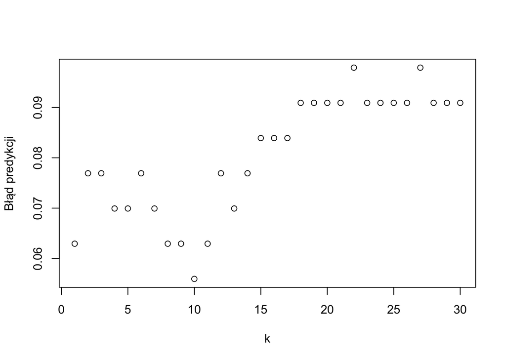

```r
library(class)

train_set <- train[,!names(ds) %in% c("id", "diagnosis", "outcome")]
test_set <- test[,!names(ds) %in% c("id", "diagnosis", "outcome")]

x = c()
y = c()

for (i in 1: 30)
{
  knn_fit <- knn(train_set, test_set, train$diagnosis, k = i)
  table(knn_fit, test$diagnosis)
  x[i] <- i
  y[i] <- mean(knn_fit != test$diagnosis)
}

plot(x, y, xlab="k", ylab="Błąd predykcji")
```

Jak widać najmniejszy błąd został uzyskany dla k w okolicach 10. Co ciekawe wraz ze wzrostem wartości parametru k, błąd rośnie.